# Project: CHURN PREDICTION

**Author:** Patricia Rodríguez Vaquero (pati.rvaquero@gmail.com)

**Purpose:** We want to predict if a client of a bank will leave it or not based on some given features.

**Target variable:** Churn.

**Features:** id_cliente, fecha_nacimiento, fecha_registro, genero, profesion, nivel_estudios, estado_civil, n_hijos, pais, nacionalidad, oficina_asociada, tipo_gestor, indicador_autonomo, volumen_haber, renta_estimada, n_operaciones_oficina, n_operaciones_web, n_operaciones_app, n_operaciones_telefono, n_operaciones_cajero, n_operaciones_tpv, saldo_total, spendpr, impsitir, ctsitir, nomina_domiciliada, pension_domiciliada, indip, indag, indss, inprod, inserv, netoapor_mes, margen_mes prodnofi_mes, comcobra, comdevol, tenen_vista, tenen_ahpat, tenen_plazo, tenen_sg_ahinv, tenen_sg_ahsis, tenen_fondo, tenen_mfondo, tenen_plpens, tenen_actfin, tenen_valor, tenen_fvivienda, tenen_fconsumo, tenen_faapp, tenen_leasing, tenen_renting, tenen_avales, tenen_sg_vida, tenen_sg_salud, tenen_sg_accid, tenen_sg_deceso, tenen_sg_pers_part, tenen_sg_pers_neg, tenen_sg_hogar, tenen_sg_auto, tenen_sg_cosa_part, tenen_sg_cosa_neg, tenen_tj_prepago, tenen_tj_debito tenen_tj_debdif, tenen_tj_credito, tenen_tj_empresa, tenen_tj_pagopla, tenen_tj_sector, tenen_tj_vincul.

**Date:** 22-05-2020

**CONTACT DETAILS:**

[GitHub](https://github.com/PatriciaVaquero)

[Twitter](https://twitter.com/patri_vaquero_)

[Linkedin](https://www.linkedin.com/in/patricia-rodr%C3%ADguez-vaquero-53425311a/)

- 1. Data Cleaning and Processing
- 2. Baseline Model
- 3. Iteration I
- 4. Iteration II
- 5. Remarks

```python
# LIBRARIES
# DATA MANIPULATION
import pandas as pd
import numpy as np
# DATA VISUALIZATION
import seaborn as sns
sns.set_style("white")
#sns.set()
import matplotlib.pyplot as plt
%matplotlib inline
# DATA MODELLING
from sklearn.model_selection import train_test_split
from sklearn.model_selection import GridSearchCV,RandomizedSearchCV, cross_val_score
from sklearn.tree import DecisionTreeClassifier
from sklearn.ensemble import AdaBoostClassifier
from sklearn.ensemble import GradientBoostingClassifier
from sklearn.ensemble import RandomForestClassifier
import xgboost as xgb
from xgboost import XGBClassifier
from catboost import CatBoostClassifier # Or CatBoostRegressor
import lightgbm as lgb
# ROC Curve
import scikitplot as skplt
# CLASSIFICATION METRICS
from sklearn.metrics import f1_score
from sklearn.metrics import accuracy_score
from sklearn.metrics import precision_score
from sklearn.metrics import classification_report, confusion_matrix
# VISUALIZATION OF MISSING VALUES
import missingno as msno
# WARNINGS
import warnings
warnings.filterwarnings("ignore")
```

## **1. Data Cleaning and Processing**

```python
pd.set_option('display.max_rows', None)
pd.set_option('display.max_columns', None)
pd.set_option('display.max_colwidth', 1000)
pd.options.display.float_format = '{:,.3f}'.format
```

```python
data=pd.read_csv("bank_data_train.csv", engine = 'c') # Engine = "c" makes the reading process faster
```

```python
data = data.drop_duplicates()
```

```python
size = data.shape # Returns the number of rows and columns
dims = data.ndim # Returns the number of dimensions
print('This dataset is {} and so, {}-dimensional'.format(size, dims))
```

```
This dataset is (88627, 72) and so, 2-dimensional
```

```python
null=data.isna().sum()/len(data)
null[null>0].sort_values()
```

```
fecha_nacimiento   0.001
profesion          0.032
estado_civil       0.160
n_hijos            0.195
nivel_estudios     0.468
tipo_gestor        0.807
ctsitir            0.967
dtype: float64
```

```python
data1 = data.copy() #we make a copy of our dataset
```

```python
data1 = data1.drop(['id_cliente','fecha_nacimiento','fecha_registro','profesion','estado_civil','n_hijos',
                   'nivel_estudios','tipo_gestor','ctsitir','volumen_haber','saldo_total','spendpr'],1)
```

```python
data1 = pd.get_dummies(data1, columns=['genero'], drop_first=True)
```

```python
data1.dtypes.head(60)
```

```
churn                       int64
pais                        int64
nacionalidad                int64
oficina_asociada            int64
indicador_autonomo          int64
renta_estimada              int64
n_operaciones_oficina       int64
n_operaciones_web           int64
n_operaciones_app           int64
n_operaciones_telefono      int64
n_operaciones_cajero        int64
n_operaciones_tpv           int64
impsitir                  float64
nomina_domiciliada          int64
pension_domiciliada         int64
indip                       int64
indag                       int64
indss                       int64
inprod                      int64
inserv                      int64
netoapor_mes              float64
margen_mes                float64
prodnofi_mes              float64
comcobra                  float64
comdevol                  float64
tenen_vista                 int64
tenen_ahpat                 int64
tenen_plazo                 int64
tenen_sg_ahinv              int64
tenen_sg_ahsis              int64
tenen_fondo                 int64
tenen_mfondo                int64
tenen_plpens                int64
tenen_actfin                int64
tenen_valor                 int64
tenen_fvivienda             int64
tenen_fconsumo              int64
tenen_faapp                 int64
tenen_leasing               int64
tenen_renting               int64
tenen_avales                int64
tenen_sg_vida               int64
tenen_sg_salud              int64
tenen_sg_accid              int64
tenen_sg_deceso             int64
tenen_sg_pers_part          int64
tenen_sg_pers_neg           int64
tenen_sg_hogar              int64
tenen_sg_auto               int64
tenen_sg_cosa_part          int64
tenen_sg_cosa_neg           int64
tenen_tj_prepago            int64
tenen_tj_debito             int64
tenen_tj_debdif             int64
tenen_tj_credito            int64
tenen_tj_empresa            int64
tenen_tj_pagopla            int64
tenen_tj_sector             int64
tenen_tj_vincul             int64
genero_M                    uint8
dtype: object
```

```python
y=data1['churn']
X=data1.drop('churn',axis=1)
X_train, X_test, y_train, y_test = train_test_split(X, y, test_size=0.3, random_state=0)
```

## **2. Baseline Model**

Creation of the simplest model that meets the required task.

- Basic cleaning of variables.
- Basic transformations of variables.
- Simple model training.
- Evaluation metrics.

**Done without Cross-Validation.**

### Baseline Model I: [Adaboost Classifier](https://scikit-learn.org/stable/modules/generated/sklearn.ensemble.AdaBoostClassifier.html)

Adaptive boosting or **AdaBoost** is one of the simplest boosting algorithms. Usually, decision trees are used for modelling. Multiple sequential models are created, each correcting the errors from the last model. AdaBoost assigns weights to the observations which are incorrectly predicted and the subsequent model works to predict these values correctly.

Below are the steps for performing the AdaBoost algorithm:

1. Initially, all observations in the dataset are given equal weights.
2. A model is built on a subset of data.
3. Using this model, predictions are made on the whole dataset.
4. Errors are calculated by comparing the predictions and actual values.
5. While creating the next model, higher weights are given to the data points which were predicted incorrectly.
6. Weights can be determined using the error value. For instance, higher the error more is the weight assigned to the observation.
7. This process is repeated until the error function does not change, or the maximum limit of the number of estimators is reached.

```python
abc = AdaBoostClassifier(DecisionTreeClassifier(max_depth=1),n_estimators=200)
abc.fit(X_train, y_train)
predictions = abc.predict(X_test)

print("Confusion Matrix:")
print(confusion_matrix(y_test, predictions))

print("Classification Report")
print(classification_report(y_test, predictions))
```

```
Confusion Matrix:
[[14784  1826]
 [ 4347  5632]]
Classification Report
              precision    recall  f1-score   support

           0       0.77      0.89      0.83     16610
           1       0.76      0.56      0.65      9979

    accuracy                           0.77     26589
   macro avg       0.76      0.73      0.74     26589
weighted avg       0.77      0.77      0.76     26589
```

```python
print(abc.score(X_train, y_train))
print(abc.score(X_test, y_test))
```

```
0.7657564718398401
0.7678363232915868
```

```python
print(f1_score(y_test, predictions))
print(accuracy_score(y_test, predictions))
print(precision_score(y_test, predictions))
```

```
0.645982680506968
0.7678363232915868
0.7551622418879056
```

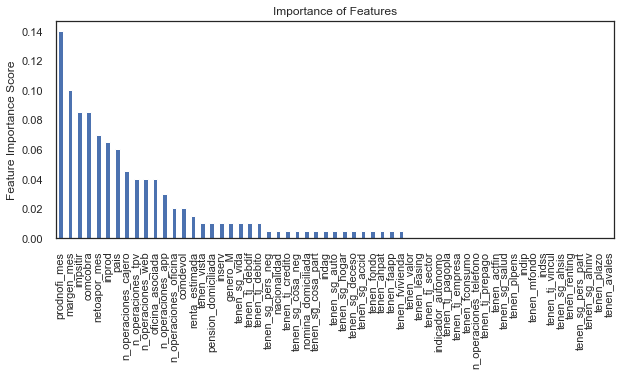

```python
predictors=list(X_train)
feat_imp = pd.Series(abc.feature_importances_, predictors).sort_values(ascending=False)
feat_imp.plot(kind='bar', title='Importance of Features')
plt.ylabel('Feature Importance Score')
plt.rcParams["figure.figsize"] = (12,4)
```

### Baseline Model II: [Gradient Boosting Classifier](https://scikit-learn.org/stable/modules/generated/sklearn.ensemble.GradientBoostingClassifier.html)

**Gradient Boosting** or GBM is another ensemble machine learning algorithm that works for both regression and classification problems. GBM uses the boosting technique, combining a number of weak learners to form a strong learner. Regression trees used as a base learner, each subsequent tree in series is built on the errors calculated by the previous tree.

```python
lr_list = [0.025, 0.05, 0.075, 0.1, 0.25, 0.5, 0.75, 1]

for learning_rate in lr_list:
    gb_clf = GradientBoostingClassifier(n_estimators=300, learning_rate=learning_rate, max_features=2, max_depth=2, random_state=0)
    gb_clf.fit(X_train, y_train)

    print("Learning rate: ", learning_rate)
    print("Accuracy score (training): {0:.3f}".format(gb_clf.score(X_train, y_train)))
    print("Accuracy score (validation): {0:.3f}".format(gb_clf.score(X_test, y_test)))
```

```
Learning rate:  0.025
Accuracy score (training): 0.741
Accuracy score (validation): 0.740
Learning rate:  0.05
Accuracy score (training): 0.756
Accuracy score (validation): 0.757
Learning rate:  0.075
Accuracy score (training): 0.762
Accuracy score (validation): 0.764
Learning rate:  0.1
Accuracy score (training): 0.767
Accuracy score (validation): 0.767
Learning rate:  0.25
Accuracy score (training): 0.782
Accuracy score (validation): 0.782
Learning rate:  0.5
Accuracy score (training): 0.782
Accuracy score (validation): 0.781
Learning rate:  0.75
Accuracy score (training): 0.785
Accuracy score (validation): 0.781
Learning rate:  1
Accuracy score (training): 0.784
Accuracy score (validation): 0.778
```

```python
gb_clf2 = GradientBoostingClassifier(n_estimators=300, learning_rate=0.75, random_state=0)
gb_clf2.fit(X_train, y_train)
predictions = gb_clf2.predict(X_test)

print("Confusion Matrix:")
print(confusion_matrix(y_test, predictions))

print("Classification Report")
print(classification_report(y_test, predictions))
```

```
Confusion Matrix:
[[14205  2405]
 [ 3329  6650]]
Classification Report
              precision    recall  f1-score   support

           0       0.81      0.86      0.83     16610
           1       0.73      0.67      0.70      9979

    accuracy                           0.78     26589
   macro avg       0.77      0.76      0.77     26589
weighted avg       0.78      0.78      0.78     26589
```

```python
print(gb_clf2.score(X_train, y_train))
print(gb_clf2.score(X_test, y_test))
```

```
0.8175150714078468
0.7843469103764714
```

```python
print(f1_score(y_test, predictions))
print(accuracy_score(y_test, predictions))
print(precision_score(y_test, predictions))
```

```
0.6987496059682673
0.7843469103764714
0.7344008834897846
```

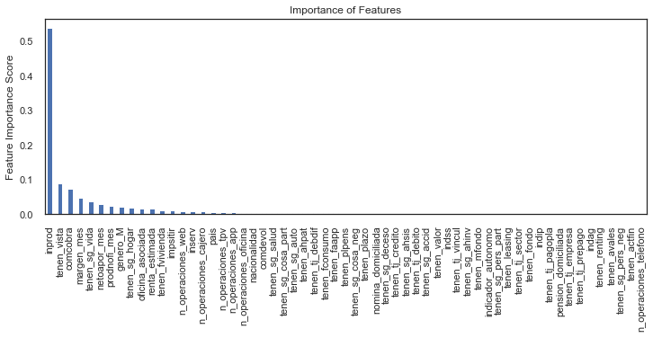

```python
predictors=list(X_train)
feat_imp = pd.Series(gb_clf2.feature_importances_, predictors).sort_values(ascending=False)
feat_imp.plot(kind='bar', title='Importance of Features')
plt.ylabel('Feature Importance Score')
plt.rcParams["figure.figsize"] = (12,4)
```

### Baseline Model III: [Random Forest Classifier](https://scikit-learn.org/stable/modules/generated/sklearn.ensemble.RandomForestClassifier.html)

**Random Forest** is another ensemble machine learning algorithm that follows the bagging technique. It is an extension of the bagging estimator algorithm. The base estimators in random forest are decision trees. Unlike bagging meta estimator, random forest randomly selects a set of features which are used to decide the best split at each node of the decision tree.

Looking at it step-by-step, this is what a random forest model does:

1. Random subsets are created from the original dataset (bootstrapping).
2. At each node in the decision tree, only a random set of features are considered to decide the best split.
3. A decision tree model is fitted on each of the subsets.
4. The final prediction is calculated by averaging the predictions from all decision trees.

*Note:* The decision trees in random forest can be built on a subset of data and features. Particularly, the sklearn model of random forest uses all features for decision tree and a subset of features are randomly selected for splitting at each node.

To sum up, Random forest randomly selects data points and features, and builds **multiple trees (Forest).**

```python
rf = RandomForestClassifier(n_estimators=300, min_samples_leaf = 3, random_state=0)
rf.fit(X_train, y_train)
predictions = rf.predict(X_test)

print("Confusion Matrix:")
print(confusion_matrix(y_test, predictions))

print("Classification Report")
print(classification_report(y_test, predictions))
```

```
Confusion Matrix:
[[14661  1949]
 [ 3505  6474]]
Classification Report
              precision    recall  f1-score   support

           0       0.81      0.88      0.84     16610
           1       0.77      0.65      0.70      9979

    accuracy                           0.79     26589
   macro avg       0.79      0.77      0.77     26589
weighted avg       0.79      0.79      0.79     26589
```

```python
print(rf.score(X_train, y_train))
print(rf.score(X_test, y_test))
```

```
0.8237693026854509
0.7948775809545301
```

```python
print(f1_score(y_test, predictions))
print(accuracy_score(y_test, predictions))
print(precision_score(y_test, predictions))
```

```
0.703619171829149
0.7948775809545301
0.7686097589932328
```

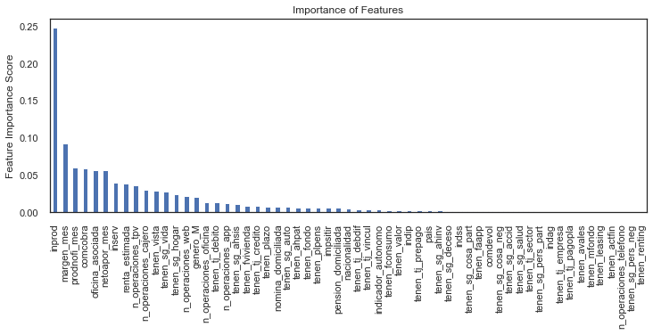

```python
predictors=list(X_train)
feat_imp = pd.Series(rf.feature_importances_, predictors).sort_values(ascending=False)
feat_imp.plot(kind='bar', title='Importance of Features')
plt.ylabel('Feature Importance Score')
plt.rcParams["figure.figsize"] = (12,4)
```

## **3. Iteration I**

First iteration to achieve a better fit through the treatment of the attributes.

- Cleaning and deeper treatment of the variables.
- Feature engineering.

```python
data.head(5)
```

|  | id_cliente | churn | fecha_nacimiento | fecha_registro | genero | profesion | nivel_estudios | estado_civil | n_hijos | pais | nacionalidad | oficina_asociada | tipo_gestor | indicador_autonomo | volumen_haber | renta_estimada | n_operaciones_oficina | n_operaciones_web | n_operaciones_app | n_operaciones_telefono | n_operaciones_cajero | n_operaciones_tpv | saldo_total | spendpr | impsitir | ctsitir | nomina_domiciliada | pension_domiciliada | indip | … |
| --- | --- | --- | --- | --- | --- | --- | --- | --- | --- | --- | --- | --- | --- | --- | --- | --- | --- | --- | --- | --- | --- | --- | --- | --- | --- | --- | --- | --- | --- | --- |
| 0 | 3202120 | 1 | 13/12/1928 0:00 | 01/10/2000 0:00 | H | 81.000 | 10.000 | C | 3.000 | 100 | 100 | 51817 | NaN | 0 | 906.492 | 2 | 1 | 0 | 0 | 0 | 0 | 0 | 8.256 | 0 | 0.000 | NaN | 0 | 1 | 0 | … |
| 1 | 5114990 | 0 | 22/07/1987 0:00 | 01/10/2010 0:00 | H | 72.000 | 30.000 | S | 0.000 | 100 | 100 | 5817 | NaN | 0 | 0 | 1 | 0 | 0 | 0 | 0 | 0 | 0 | 0 | 0 | 0.000 | NaN | 0 | 0 | 0 | … |
| 2 | 2216174 | 1 | 26/08/1986 0:00 | 01/04/1994 0:00 | M | 73.000 | 30.000 | S | 0.000 | 100 | 100 | 51821 | NaN | 0 | 2.278.884 | 2 | 0 | 36 | 0 | 0 | 1 | 15 | 8.106.795 | 48.030.168 | 0.000 | NaN | 1 | 0 | 1 | … |
| 3 | 5760264 | 0 | 12/08/2003 0:00 | 01/07/2014 0:00 | M | 86.000 | nan | S | nan | 100 | 100 | 67187 | NaN | 0 | 0 | 1 | 0 | 0 | 0 | 0 | 0 | 0 | 15.651 | 0 | 0.000 | NaN | 0 | 0 | 0 | … |
| 4 | 2216101 | 0 | 12/07/1974 0:00 | 01/04/1994 0:00 | H | 11.000 | 30.000 | S | 0.000 | 100 | 100 | 51815 | NaN | 0 | 5.631.432 | 3 | 5 | 0 | 0 | 0 | 1 | 8 | 17.518.067 | 11245.14 | 0.000 | NaN | 0 | 0 | 0 | … |

```python
data.shape
```

```
(88627, 72)
```

```python
data.dtypes.head(60)
```

```
id_cliente                  int64
churn                       int64
fecha_nacimiento           object
fecha_registro             object
genero                     object
profesion                 float64
nivel_estudios            float64
estado_civil               object
n_hijos                   float64
pais                        int64
nacionalidad                int64
oficina_asociada            int64
tipo_gestor                object
indicador_autonomo          int64
volumen_haber              object
renta_estimada              int64
n_operaciones_oficina       int64
n_operaciones_web           int64
n_operaciones_app           int64
n_operaciones_telefono      int64
n_operaciones_cajero        int64
n_operaciones_tpv           int64
saldo_total                object
spendpr                    object
impsitir                  float64
ctsitir                    object
nomina_domiciliada          int64
pension_domiciliada         int64
indip                       int64
indag                       int64
indss                       int64
inprod                      int64
inserv                      int64
netoapor_mes              float64
margen_mes                float64
prodnofi_mes              float64
comcobra                  float64
comdevol                  float64
tenen_vista                 int64
tenen_ahpat                 int64
tenen_plazo                 int64
tenen_sg_ahinv              int64
tenen_sg_ahsis              int64
tenen_fondo                 int64
tenen_mfondo                int64
tenen_plpens                int64
tenen_actfin                int64
tenen_valor                 int64
tenen_fvivienda             int64
tenen_fconsumo              int64
tenen_faapp                 int64
tenen_leasing               int64
tenen_renting               int64
tenen_avales                int64
tenen_sg_vida               int64
tenen_sg_salud              int64
tenen_sg_accid              int64
tenen_sg_deceso             int64
tenen_sg_pers_part          int64
tenen_sg_pers_neg           int64
dtype: object
```

```python
data.describe()
```

|  | id_cliente | churn | profesion | nivel_estudios | n_hijos | pais | nacionalidad | oficina_asociada | indicador_autonomo | renta_estimada | n_operaciones_oficina | n_operaciones_web | n_operaciones_app | n_operaciones_telefono | n_operaciones_cajero | n_operaciones_tpv | impsitir | nomina_domiciliada | pension_domiciliada | indip | indag | indss | inprod | inserv | netoapor_mes | margen_mes | prodnofi_mes | comcobra | comdevol | … |
| --- | --- | --- | --- | --- | --- | --- | --- | --- | --- | --- | --- | --- | --- | --- | --- | --- | --- | --- | --- | --- | --- | --- | --- | --- | --- | --- | --- | --- | --- | --- |
| count | 88,627.000 | 88,627.000 | 85,834.000 | 47,187.000 | 71,327.000 | 88,627.000 | 88,627.000 | 88,627.000 | 88,627.000 | 88,627.000 | 88,627.000 | 88,627.000 | 88,627.000 | 88,627.000 | 88,627.000 | 88,627.000 | 88,627.000 | 88,627.000 | 88,627.000 | 88,627.000 | 88,627.000 | 88,627.000 | 88,627.000 | 88,627.000 | 88,627.000 | 88,627.000 | 88,627.000 | 88,627.000 | 88,627.000 | … |
| mean | 3,885,011.077 | 0.373 | 71.901 | 32.110 | 0.735 | 100.159 | 106.529 | 51,719.459 | 0.058 | 1.657 | 0.512 | 8.422 | 13.691 | 0.002 | 2.086 | 4.105 | 272.247 | 0.207 | 0.185 | 0.065 | 0.018 | 0.043 | 3.144 | 2.747 | 232.777 | 27.809 | 5.865 | 5.959 | 0.298 | … |
| std | 2,949,947.869 | 0.484 | 17.281 | 16.032 | 1.111 | 12.460 | 57.641 | 26,321.029 | 0.234 | 1.395 | 1.356 | 103.937 | 64.480 | 0.142 | 4.527 | 9.932 | 6,645.043 | 0.405 | 0.388 | 0.246 | 0.178 | 0.202 | 4.074 | 3.316 | 7,699.935 | 81.550 | 23.987 | 30.337 | 10.833 | … |
| min | 154.000 | 0.000 | 10.000 | 10.000 | 0.000 | 1.000 | 1.000 | 27.000 | 0.000 | 0.000 | 0.000 | 0.000 | 0.000 | 0.000 | 0.000 | 0.000 | 0.000 | 0.000 | 0.000 | 0.000 | 0.000 | 0.000 | 0.000 | 0.000 | -801,551.680 | -746.540 | -568.190 | -26.200 | 0.000 | … |
| 25% | 986,130.000 | 0.000 | 72.000 | 20.000 | 0.000 | 100.000 | 100.000 | 21,727.000 | 0.000 | 1.000 | 0.000 | 0.000 | 0.000 | 0.000 | 0.000 | 0.000 | 0.000 | 0.000 | 0.000 | 0.000 | 0.000 | 0.000 | 1.000 | 0.000 | -17.445 | 0.000 | 0.000 | 0.000 | 0.000 | … |
| 50% | 3,457,066.000 | 0.000 | 74.000 | 30.000 | 0.000 | 100.000 | 100.000 | 65,287.000 | 0.000 | 2.000 | 0.000 | 0.000 | 0.000 | 0.000 | 0.000 | 0.000 | 0.000 | 0.000 | 0.000 | 0.000 | 0.000 | 0.000 | 2.000 | 1.000 | 0.000 | 2.260 | 0.520 | 0.000 | 0.000 | … |
| 75% | 6,975,137.500 | 1.000 | 82.000 | 50.000 | 2.000 | 100.000 | 100.000 | 68,772.000 | 0.000 | 2.000 | 1.000 | 0.000 | 0.000 | 0.000 | 2.000 | 3.000 | 0.000 | 0.000 | 0.000 | 0.000 | 0.000 | 0.000 | 4.000 | 5.000 | 199.530 | 22.720 | 4.160 | 2.400 | 0.000 | … |
| max | 10,214,750.000 | 1.000 | 91.000 | 70.000 | 52.000 | 800.000 | 958.000 | 88,287.000 | 1.000 | 5.000 | 58.000 | 19,608.000 | 1,977.000 | 24.000 | 122.000 | 358.000 | 989,984.030 | 1.000 | 1.000 | 1.000 | 2.000 | 1.000 | 50.000 | 19.000 | 848,431.640 | 5,185.340 | 1,574.340 | 6,642.750 | 1,956.490 | … |

```python
data.info()
```

```
<class 'pandas.core.frame.DataFrame'>
Int64Index: 88627 entries, 0 to 89995
Data columns (total 72 columns):
 #   Column                  Non-Null Count  Dtype
---  ------                  --------------  -----
 0   id_cliente              88627 non-null  int64
 1   churn                   88627 non-null  int64
 2   fecha_nacimiento        88534 non-null  object
 3   fecha_registro          88627 non-null  object
 4   genero                  88627 non-null  object
 5   profesion               85834 non-null  float64
 6   nivel_estudios          47187 non-null  float64
 7   estado_civil            74413 non-null  object
 8   n_hijos                 71327 non-null  float64
 9   pais                    88627 non-null  int64
```

[output cut: 64 more lines]

```python
data.churn.describe() #some statistics of my target variable "churn"
```

```
count   88,627.000
mean         0.373
std          0.484
min          0.000
25%          0.000
50%          0.000
75%          1.000
max          1.000
Name: churn, dtype: float64
```

```python
number_churn = data.churn.value_counts() #sample a little unbalanced, but nothing to worry about
number_churn
```

```
0    55555
1    33072
Name: churn, dtype: int64
```

```python
percentage_churn = round(data.churn.value_counts()/len(data['churn']),2)
percentage_churn
```

```
0   0.630
1   0.370
Name: churn, dtype: float64
```

```python
churn_df ={'Number_churn':number_churn, 'Percentage_churn (%)':percentage_churn}
result = pd.DataFrame(churn_df)
result
```

|  | Number_churn | Percentage_churn (%) |
| --- | --- | --- |
| 0 | 55555 | 0.630 |
| 1 | 33072 | 0.370 |

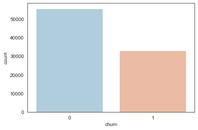

```python
sns.countplot(x='churn',data=data,palette='RdBu_r');
#sns.set(rc={'figure.figsize':(10,5)});
```

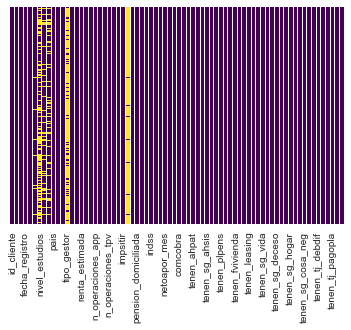

```python
sns.heatmap(data.isnull(),yticklabels=False,cbar=False,cmap='viridis'); #visualizar missing values
```

```python
data.isnull().sum().head(60) #missing values
```

```
id_cliente                    0
churn                         0
fecha_nacimiento             93
fecha_registro                0
genero                        0
profesion                  2793
nivel_estudios            41440
estado_civil              14214
n_hijos                   17300
pais                          0
nacionalidad                  0
oficina_asociada              0
tipo_gestor               71492
indicador_autonomo            0
volumen_haber                 0
renta_estimada                0
n_operaciones_oficina         0
n_operaciones_web             0
n_operaciones_app             0
n_operaciones_telefono        0
n_operaciones_cajero          0
n_operaciones_tpv             0
saldo_total                   0
spendpr                       0
impsitir                      0
ctsitir                   85711
nomina_domiciliada            0
pension_domiciliada           0
indip                         0
indag                         0
indss                         0
inprod                        0
inserv                        0
netoapor_mes                  0
margen_mes                    0
prodnofi_mes                  0
comcobra                      0
comdevol                      0
tenen_vista                   0
tenen_ahpat                   0
tenen_plazo                   0
tenen_sg_ahinv                0
tenen_sg_ahsis                0
tenen_fondo                   0
tenen_mfondo                  0
tenen_plpens                  0
tenen_actfin                  0
tenen_valor                   0
tenen_fvivienda               0
tenen_fconsumo                0
tenen_faapp                   0
tenen_leasing                 0
tenen_renting                 0
tenen_avales                  0
tenen_sg_vida                 0
tenen_sg_salud                0
tenen_sg_accid                0
tenen_sg_deceso               0
tenen_sg_pers_part            0
tenen_sg_pers_neg             0
dtype: int64
```

```python
#Higlight the null value
data.sample(10).style.highlight_null(null_color = 'red')
```

|  | id_cliente | churn | fecha_nacimiento | fecha_registro | genero | profesion | nivel_estudios | estado_civil | n_hijos | pais | nacionalidad | oficina_asociada | tipo_gestor | indicador_autonomo | volumen_haber | renta_estimada | n_operaciones_oficina | n_operaciones_web | n_operaciones_app | n_operaciones_telefono | n_operaciones_cajero | n_operaciones_tpv | saldo_total | spendpr | impsitir | ctsitir | nomina_domiciliada | pension_domiciliada | indip | … |
| --- | --- | --- | --- | --- | --- | --- | --- | --- | --- | --- | --- | --- | --- | --- | --- | --- | --- | --- | --- | --- | --- | --- | --- | --- | --- | --- | --- | --- | --- | --- |
| 24863 | 114007 | 1 | 18/08/1963 0:00 | 01/02/1968 0:00 | M | 81.000000 | 20.000000 | nan | 0.000000 | 100 | 100 | 7217 | nan | 0 | 2238.48 | 2 | 5 | 0 | 0 | 0 | 5 | 0 | 22.849.433 | 0 | 0.000000 | nan | 0 | 1 | 0 | … |
| 8619 | 7423102 | 0 | 25/02/1965 0:00 | 01/01/2005 0:00 | M | 91.000000 | nan | nan | 0.000000 | 100 | 100 | 68837 | nan | 0 | 1.598.184 | 2 | 0 | 0 | 0 | 0 | 1 | 13 | 100513.68 | 73.92 | 0.000000 | nan | 0 | 0 | 1 | … |
| 51679 | 178648 | 0 | 08/02/1918 0:00 | 01/06/1970 0:00 | M | 81.000000 | nan | S | 0.000000 | 100 | 100 | 72212 | nan | 0 | 0 | 2 | 0 | 0 | 0 | 0 | 0 | 0 | 964.638 | 0 | 0.000000 | nan | 0 | 0 | 0 | … |
| 2386 | 16834 | 1 | 19/10/1923 0:00 | 01/02/1953 0:00 | H | 81.000000 | 50.000000 | S | 0.000000 | 100 | 100 | 81711 | nan | 0 | 0 | 2 | 1 | 0 | 0 | 0 | 1 | 0 | 19.053.604 | 0 | 0.000000 | nan | 0 | 0 | 0 | … |
| 88497 | 4740110 | 0 | 07/02/1945 0:00 | 01/07/2008 0:00 | M | 82.000000 | nan | C | 0.000000 | 100 | 100 | 67176 | nan | 0 | 0 | 0 | 0 | 0 | 0 | 0 | 0 | 0 | 0 | 0 | 0.000000 | nan | 0 | 0 | 0 | … |
| 12953 | 2270144 | 1 | 20/09/1972 0:00 | 01/07/2014 0:00 | H | 33.000000 | 40.000000 | C | 0.000000 | 100 | 100 | 65272 | nan | 1 | 0 | 1 | 0 | 0 | 0 | 0 | 0 | 0 | 70.490 | 0 | 0.000000 | nan | 0 | 0 | 0 | … |
| 57817 | 445046 | 0 | 01/01/1953 0:00 | 01/03/2017 0:00 | H | 33.000000 | nan | nan | nan | 100 | 100 | 67172 | nan | 1 | 0 | 0 | 0 | 0 | 0 | 0 | 0 | 0 | 28.841.033 | 0 | 0.000000 | nan | 0 | 0 | 0 | … |
| 89239 | 396347 | 0 | 27/03/1974 0:00 | 01/10/1974 0:00 | H | 73.000000 | 30.000000 | P | 0.000000 | 100 | 100 | 27217 | nan | 0 | 1.943.064 | 2 | 0 | 0 | 101 | 0 | 2 | 5 | 71.838.853 | 82.767.372 | 0.000000 | nan | 1 | 0 | 0 | … |
| 50671 | 1036191 | 0 | 28/11/1925 0:00 | 01/09/1983 0:00 | H | 81.000000 | 20.000000 | S | nan | 100 | 100 | 81711 | GERENTE_BP | 0 | 2.709.516 | 5 | 0 | 0 | 0 | 0 | 0 | 0 | 450.021.939 | 0 | 0.000000 | nan | 0 | 1 | 0 | … |
| 37576 | 7026745 | 1 | 03/01/1937 0:00 | 01/01/2005 0:00 | M | 81.000000 | nan | C | 0.000000 | 100 | 100 | 68861 | GERENTE_BP | 0 | 0 | 0 | 0 | 0 | 0 | 0 | 0 | 0 | 0 | 0 | 0.000000 | nan | 0 | 0 | 0 | … |

```python
null=data.isna().sum()/len(data)
null[null>0].sort_values() # Percentages of missing values in our features
```

```
fecha_nacimiento   0.001
profesion          0.032
estado_civil       0.160
n_hijos            0.195
nivel_estudios     0.468
tipo_gestor        0.807
ctsitir            0.967
dtype: float64
```

### Heatmap

** The missingno correlation heatmap measures nullity correlation: how strongly the presence or absence of one variable affects the presence of another:

Nullity correlation ranges from -1 (if one variable appears the other definitely does not) to 0 (variables appearing or not appearing have no effect on one another) to 1 (if one variable appears the other definitely also does).

Variables that are always full or always empty have no meaningful correlation, and so are silently removed from the visualization. **

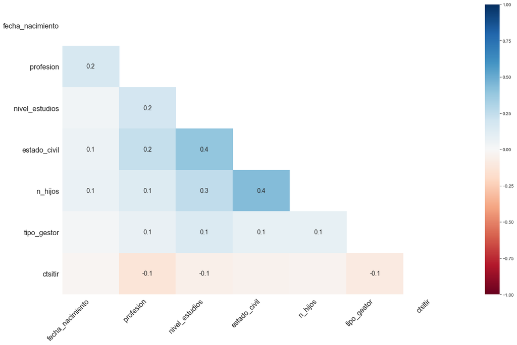

```python
msno.heatmap(data); ##visualizing missing values
```

```python
data.corr().style.background_gradient(cmap = 'Blues') # correlation matrix of numerical features
```

[output not shown]